# Part 1: Data Exploration of Trace Elements in Apatite

## 1. R markdown

We will use R markdown to thoroughly display the data of my MSc dissertation called “*Trace elements geochemistry of apatite and magnetite in gold systems of the Alta Floresta mineral province: Petrogenic and metallogenic implications*”, so that the experimental results contained in this work can be reproduced. This is a vital, though often neglected, part of any scientific endeavour. By exposing the nuts and bolts of my work, it can be continued, incremented, contested, and even used as a reference on how to do a geochemical analysis from the ground up using R.

For the complete theoretical framework, the reader is referred to the full dissertation available [here](http://hdl.handle.net/11449/193761).

We will start by importing the necessary libraries into R:

```r
library(ggplot2) #for beautiful plots
  theme_set(theme_classic()) #to give plots a standard scientific flair
library(kableExtra) #for beautiful tables
library(knitr) #for rendering it on the web
  knitr::opts_knit$set(root.dir= normalizePath('..'))
  knitr::opts_chunk$set(error = FALSE)
```

## 2. Trace elements in apatite

In this R markdown, we will only evaluate trace elements in apatite. Magnetite will be evaluated in another document.

Why are trace elements in apatite important? The incorporation of certain trace elements in apatite may indicate specific physico-chemical processes in a mineral system. These processes generally involve the percolation of metal-bearing fluids in a rock substratum. If those processes are known to be ore-related, then the chemical composition of apatite may mirror the composition of the mineralising fluids, which may be a good indicator that you are near a new mineral deposit.The same would theoretically work for magnetite as well.

We collected our own rock samples in the field by visiting mineral prospects in the Alta Floresta mineral province. We examined apatite grains via EMPA and LA-ICP-MS, two of most robust geochemical techniques available. The EMPA gave our major elements (exhibited in % wt.) and the LA-ICP-MS gave our trace elements (exhibited in ppm). We load the data here:

```r
geochem_ap <- read.csv2('C:/Users/Pedro/Documents/Rconsole/Apatite_git/geochem_ap.csv',
                        header = TRUE,
                        stringsAsFactors=TRUE,
                        na = "NA",
                        dec = ".",
                        sep=";")
kbl(geochem_ap) %>%
  kable_paper() %>%
  scroll_box(width = "100%", height = "400px")
```

| Sample_ID | Sample | Deposit | Nature | Zone | Class | CL | F_pct | Si_pct | Mg_pct | Na_pct | Ca_pct | P_pct | Cl_pct | Fe_pct | Mn_pct | Ce_pct | La_pct | Nd_pct | B_ppm | Mg_ppm | Si_ppm | P_ppm | Ca_ppm | Sc_ppm | Ti_ppm | V_ppm | Mn_ppm | Fe_ppm | Ga_ppm | … |
| --- | --- | --- | --- | --- | --- | --- | --- | --- | --- | --- | --- | --- | --- | --- | --- | --- | --- | --- | --- | --- | --- | --- | --- | --- | --- | --- | --- | --- | --- | --- |
| B6_ap_1_1 | B6 | X1 deposit | Hydrothermal | Hydrothermal | X1 deposit | CL-green | 3.51 | 0.08 | 0.02 | 0.27 | 37.76 | 17.56 | 0.10 | 0.25 | 0.84 | 0.19 | 0.06 | 0.08 | NA | NA | NA | NA | NA | NA | NA | NA | NA | NA | NA | … |
| B6_ap_1_2 | B6 | X1 deposit | Hydrothermal | Hydrothermal | X1 deposit | CL-green | 4.04 | 0.11 | 0.04 | 0.20 | 37.68 | 17.82 | 0.10 | 0.19 | 1.02 | 0.24 | 0.06 | 0.11 | NA | NA | NA | NA | NA | NA | NA | NA | NA | NA | NA | … |
| B6_ap_2_1 | B6 | X1 deposit | Hydrothermal | Hydrothermal | X1 deposit | CL-green | 3.64 | 0.03 | 0.03 | 0.25 | 37.57 | 17.49 | 0.15 | 0.29 | 1.09 | 0.16 | 0.05 | 0.11 | 3.05 | 389.43 | 2760.73 | 157416.05 | 375620.8 | 3.84 | 811.01 | 5.31 | 11560.24 | 2344.03 | 0.17 | … |
| B6_ap_3_1 | B6 | X1 deposit | Hydrothermal | Hydrothermal | X1 deposit | CL-green | 3.85 | 0.08 | 0.04 | 0.24 | 37.25 | 17.88 | 0.19 | 0.31 | 1.17 | 0.16 | 0.07 | 0.11 | 2.00 | 667.72 | 2535.87 | 160435.22 | 372542.9 | 2.85 | 778.63 | 4.43 | 11781.36 | 2996.92 | 0.47 | … |
| B6_ap_3_2 | B6 | X1 deposit | Hydrothermal | Hydrothermal | X1 deposit | CL-green | 3.69 | 0.13 | 0.04 | 0.17 | 37.53 | 17.56 | 0.17 | 0.26 | 1.03 | 0.16 | 0.04 | 0.12 | 5.00 | 392.63 | 2408.72 | 140917.86 | 375350.2 | 2.77 | 784.73 | 8.59 | 11678.81 | 2267.10 | 0.15 | … |
| B6_ap_4_1 | B6 | X1 deposit | Hydrothermal | Hydrothermal | X1 deposit | CL-green | 3.91 | 0.05 | 0.04 | 0.16 | 37.60 | 17.67 | 0.20 | 0.29 | 1.13 | 0.14 | 0.06 | 0.08 | 2.51 | 394.77 | 2372.73 | 135010.08 | 375997.1 | 1.60 | 781.76 | 3.97 | 10798.30 | 1968.65 | 0.14 | … |
| B6_ap_5_1 | B6 | X1 deposit | Hydrothermal | Hydrothermal | X1 deposit | CL-green | 3.99 | NA | 0.01 | 0.10 | 38.86 | 18.21 | 0.06 | 0.07 | 0.65 | 0.08 | NA | 0.06 | 3.05 | 128.71 | 2743.58 | 128547.80 | 388643.7 | 0.32 | 789.94 | 0.33 | 6217.99 | 1179.15 | 0.17 | … |
| B6_ap_6_1 | B6 | X1 deposit | Hydrothermal | Hydrothermal | X1 deposit | CL-green | 4.04 | 0.03 | 0.03 | 0.11 | 37.97 | 17.92 | 0.16 | 0.20 | 1.03 | 0.14 | 0.05 | 0.08 | 2.81 | 379.68 | 2845.04 | 118958.40 | 379732.8 | 1.83 | 759.34 | 3.09 | 10220.28 | 2565.02 | 0.39 | … |
| B6_ap_6_2 | B6 | X1 deposit | Hydrothermal | Hydrothermal | X1 deposit | CL-green | 4.10 | 0.02 | 0.03 | 0.12 | 38.33 | 17.77 | 0.11 | 0.20 | 0.84 | 0.11 | 0.05 | 0.07 | 2.75 | 301.59 | 2878.25 | 107340.56 | 383277.0 | 1.67 | 750.51 | 3.48 | 7473.14 | 2235.72 | 0.38 | … |
| B6_ap_7_1 | B6 | X1 deposit | Hydrothermal | Hydrothermal | X1 deposit | CL-green | 3.78 | 0.02 | 0.01 | 0.14 | 38.48 | 18.10 | 0.11 | 0.07 | 0.64 | 0.16 | 0.05 | 0.08 | NA | NA | NA | NA | NA | NA | NA | NA | NA | NA | NA | … |
| PTO19_ap_22 | PTO19 | Francisco deposit | Igneous | Unaltered | Francisco deposit | CL-green | 3.27 | 0.12 | 0.05 | 0.15 | 38.50 | 17.79 | 0.18 | 0.16 | 0.09 | 0.40 | 0.18 | 0.18 | NA | NA | NA | NA | NA | NA | NA | NA | NA | NA | NA | … |
| GT-2_ap_1_1 | GT-2 | Pé Quente deposit | Igneous | Unaltered | Pé Quente deposit (type 1) | CL-yellow | 2.57 | 0.10 | 0.00 | 0.11 | 39.40 | 17.73 | 0.69 | 0.04 | 0.09 | 0.12 | 0.00 | 0.04 | NA | NA | NA | NA | NA | NA | NA | NA | NA | NA | NA | … |
| GT-2_ap_1_2 | GT-2 | Pé Quente deposit | Igneous | Unaltered | Pé Quente deposit (type 1) | CL-yellow | 2.45 | 0.04 | 0.01 | 0.07 | 39.50 | 18.03 | 0.72 | 0.07 | 0.07 | 0.05 | 0.04 | 0.03 | NA | NA | NA | NA | NA | NA | NA | NA | NA | NA | NA | … |
| GT-2_ap_1_3 | GT-2 | Pé Quente deposit | Igneous | Unaltered | Pé Quente deposit (type 1) | CL-yellow | 2.74 | 0.07 | NA | 0.07 | 39.66 | 18.02 | 0.52 | 0.02 | 0.07 | 0.09 | NA | 0.04 | NA | NA | NA | NA | NA | NA | NA | NA | NA | NA | NA | … |
| GT-2_ap_2_1 | GT-2 | Pé Quente deposit | Igneous | Unaltered | Pé Quente deposit (type 1) | CL-yellow | 2.69 | 0.09 | 0.01 | 0.12 | 39.76 | 17.83 | 0.64 | 0.04 | 0.10 | 0.08 | 0.05 | 0.02 | NA | NA | NA | NA | NA | NA | NA | NA | NA | NA | NA | … |
| GT-2_ap_2_2 | GT-2 | Pé Quente deposit | Igneous | Unaltered | Pé Quente deposit (type 1) | CL-yellow | 2.78 | 0.05 | NA | 0.05 | 39.73 | 18.02 | 0.50 | 0.06 | 0.09 | 0.06 | 0.08 | 0.07 | NA | NA | NA | NA | NA | NA | NA | NA | NA | NA | NA | … |
| GT-2_ap_3_1 | GT-2 | Pé Quente deposit | Igneous | Unaltered | Pé Quente deposit (type 1) | CL-yellow | 2.67 | 0.06 | 0.01 | 0.06 | 39.88 | 18.04 | 0.20 | 0.02 | 0.08 | 0.11 | 0.02 | 0.04 | 3.40 | 330.56 | 5176.25 | 215900.72 | 398848.9 | 0.34 | 841.09 | 5.73 | 729.42 | 944.41 | 0.16 | … |
| GT-2_ap_3_2 | GT-2 | Pé Quente deposit | Igneous | Unaltered | Pé Quente deposit (type 1) | CL-yellow | 2.92 | 0.08 | 0.00 | 0.05 | 40.10 | 18.11 | 0.26 | 0.09 | 0.07 | 0.06 | 0.01 | 0.03 | 2.94 | 290.46 | 9248.60 | 212790.47 | 400965.2 | 0.31 | 783.81 | 9.90 | 652.75 | 565.16 | 0.12 | … |
| GT-2_ap_4_1 | GT-2 | Pé Quente deposit | Igneous | Unaltered | Pé Quente deposit (type 1) | CL-yellow | 2.81 | 0.06 | 0.00 | 0.06 | 39.87 | 18.25 | 0.25 | 0.04 | 0.06 | 0.07 | 0.05 | 0.04 | 54.00 | 10210.59 | 176472.27 | 103741.28 | 398665.2 | 2.58 | 860.98 | 21.60 | 742.65 | 2999.59 | 7.21 | … |
| GT-2_ap_4_2 | GT-2 | Pé Quente deposit | Igneous | Unaltered | Pé Quente deposit (type 1) | CL-yellow | 2.72 | 0.08 | 0.00 | 0.08 | 39.99 | 17.80 | 0.29 | 0.02 | 0.06 | 0.07 | 0.02 | 0.08 | 5.05 | 2293.89 | 11240.29 | 133812.38 | 399885.9 | 1.39 | 937.24 | 24.63 | 726.71 | 3866.90 | 0.69 | … |
| GT-2_ap_4_4 | GT-2 | Pé Quente deposit | Igneous | Unaltered | Pé Quente deposit (type 1) | CL-yellow | 2.72 | 0.10 | 0.00 | 0.06 | 39.66 | 18.08 | 0.24 | 0.04 | 0.07 | 0.12 | 0.01 | 0.04 | 3.85 | 3249.27 | 55775.70 | 135494.41 | 396557.6 | 0.40 | 781.69 | 7.20 | 703.79 | 643.04 | 1.69 | … |
| GT-2_ap_5_1 | GT-2 | Pé Quente deposit | Igneous | Unaltered | Pé Quente deposit (type 1) | CL-yellow | 2.72 | 0.04 | 0.00 | 0.02 | 39.87 | 18.10 | 0.22 | 0.01 | 0.06 | 0.11 | NA | 0.02 | 7.66 | 231.18 | 5479.52 | 191660.67 | 398667.4 | 0.49 | 788.95 | 12.77 | 639.71 | 674.87 | 0.38 | … |
| GT-2_ap_6_1 | GT-2 | Pé Quente deposit | Igneous | Unaltered | Pé Quente deposit (type 1) | CL-yellow | 2.60 | 0.17 | 0.10 | 0.05 | 39.64 | 18.07 | 0.19 | 0.16 | 0.07 | 0.07 | NA | 0.03 | 7.88 | 258.32 | 1528.26 | 189655.98 | 396422.5 | 0.77 | 788.88 | 23.60 | 691.24 | 822.79 | 0.37 | … |
| GT-2_ap_6_2 | GT-2 | Pé Quente deposit | Igneous | Unaltered | Pé Quente deposit (type 1) | CL-yellow | 2.90 | 0.06 | 0.01 | 0.07 | 39.98 | 18.00 | 0.18 | 0.03 | 0.06 | 0.08 | 0.06 | 0.01 | 8.65 | 231.52 | 2016.66 | 187166.73 | 399803.8 | 0.28 | 845.84 | 24.79 | 707.53 | 801.44 | 0.27 | … |
| GT-2_ap_6_3 | GT-2 | Pé Quente deposit | Igneous | Unaltered | Pé Quente deposit (type 1) | CL-yellow | 2.68 | 0.04 | NA | 0.06 | 39.85 | 17.98 | 0.22 | 0.04 | 0.06 | 0.13 | 0.09 | 0.06 | 2.62 | 190.73 | 5386.71 | 174627.45 | 398529.4 | 0.28 | 805.14 | 24.94 | 714.91 | 498.63 | 0.37 | … |
| GT-2_ap_7_1 | GT-2 | Pé Quente deposit | Igneous | Unaltered | Pé Quente deposit (type 1) | CL-yellow | 2.71 | 0.08 | 0.00 | 0.08 | 39.93 | 17.82 | 0.22 | 0.04 | 0.06 | 0.07 | 0.00 | NA | 14.30 | 68.91 | 16540.48 | 164079.42 | 399253.4 | 0.58 | 779.63 | 10.47 | 546.78 | 647.62 | 0.27 | … |
| GT-2_ap_7_2 | GT-2 | Pé Quente deposit | Igneous | Unaltered | Pé Quente deposit (type 1) | CL-yellow | 2.67 | 0.08 | 0.00 | 0.09 | 39.47 | 18.04 | 0.21 | 0.12 | 0.06 | 0.16 | 0.06 | 0.08 | 11.98 | 686.58 | 3197.20 | 149266.53 | 394661.5 | 1.23 | 2210.80 | 19.13 | 503.32 | 765.34 | 0.90 | … |
| GT-2_ap_8_1 | GT-2 | Pé Quente deposit | Igneous | Unaltered | Pé Quente deposit (type 1) | CL-yellow | 2.90 | 0.02 | 0.00 | 0.02 | 40.08 | 18.31 | 0.17 | 0.05 | 0.08 | 0.13 | 0.02 | 0.05 | 2.92 | 76.59 | 2096.00 | 156325.14 | 400762.9 | 0.80 | 826.02 | 9.94 | 682.30 | 496.38 | 0.35 | … |
| GT-2_ap_8_2 | GT-2 | Pé Quente deposit | Igneous | Unaltered | Pé Quente deposit (type 1) | CL-yellow | 2.90 | 0.06 | 0.01 | 0.04 | 39.86 | 18.00 | 0.14 | 0.02 | 0.08 | 0.04 | NA | 0.02 | 12.19 | 142.29 | 2084.46 | 149085.39 | 398649.5 | 0.26 | 788.43 | 8.70 | 649.88 | 411.05 | 0.16 | … |
| GT-2_ap_9_1 | GT-2 | Pé Quente deposit | Igneous | Unaltered | Pé Quente deposit (type 1) | CL-yellow | 2.75 | 0.08 | 0.00 | 0.08 | 39.79 | 18.21 | 0.27 | 0.03 | 0.07 | 0.06 | 0.04 | 0.05 | NA | NA | NA | NA | NA | NA | NA | NA | NA | NA | NA | … |

[output cut: 101 more lines]

## 3. Multielemental boxplots

Boxplots are incredibly useful when analysing multiple elements from multiple sources as we did, and may be useful for other kinds of geochemical analysis as well. Geochemists depend on these boxplots to evaluate the relationships between the chemical results they obtained via EMPA and LA-ICP-MS and their petrographical analysis, which is the step undertook prior to the chemical analysis, in which the geochemist designated all the *a priori* classifications for the observed mineral morphologies and textures.

However, before displaying the chemical analysis, we need to correct some of the boxplots, because a few outliers inhibited us from seeing the right scales of elemental concentrations. Otherwise, we would not be able to visualise the proportions between each boxplot, and would not be able to evaluate the relations between them correctly.

In our case, the elements that would need to be rescaled are Mg, Sr, Ba, Pb, Ti, V and As. They were selected by trial-and-error, once the multielemental boxplots were made and the incongruencies were visually detected.

The code for deleting the outliers from the elemental features follows:

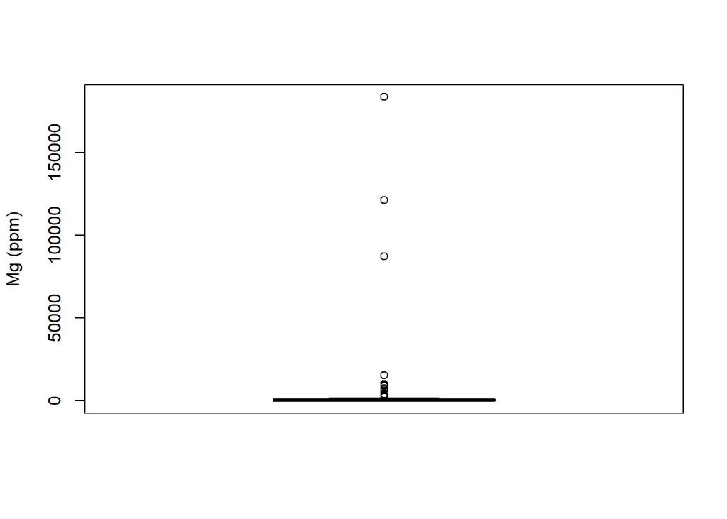

```r
#Removing outliers from Mg concentrations
outliersMg <- boxplot(geochem_ap$Mg_ppm, ylab="Mg (ppm)")$out
```

```r
print("Mg outliers:")
```

```
## [1] "Mg outliers:"
```

```r
print(outliersMg)
```

```
##  [1]  10210.59   2293.89   3249.27  15430.14   6117.28   2932.85   9673.03
##  [8] 121100.70   7601.19  87376.36  87130.60   8760.37   3895.30 183513.36
## [15]   2855.67
```

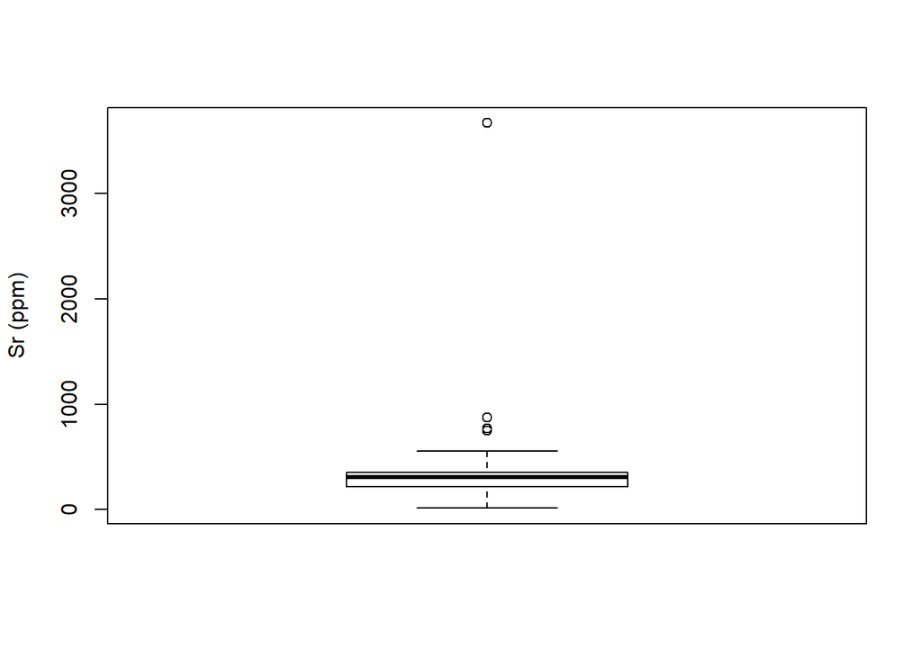

```r
outap_Mg <- geochem_ap[-which(geochem_ap$Mg_ppm %in% outliersMg),]

#Removing outliers from Sr concentrations
outliersSr <- boxplot(geochem_ap$Sr_ppm, ylab="Sr (ppm)")$out
```

```r
print("Sr outliers:")
```

```
## [1] "Sr outliers:"
```

```r
print(outliersSr)
```

```
## [1] 3665.31  767.69  870.95  751.91
```

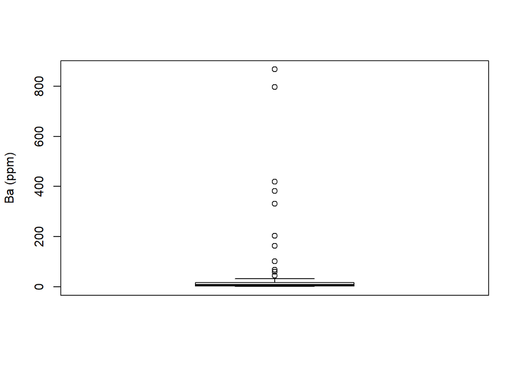

```r
outap_Sr <- geochem_ap[-which(geochem_ap$Sr_ppm %in% outliersSr),]

#Removing outliers from Ba concentrations
outliersBa <- boxplot(geochem_ap$Ba_ppm, ylab="Ba (ppm)")$out
```

```r
print("Ba outliers:")
```

```
## [1] "Ba outliers:"
```

```r
print(outliersBa)
```

```
##  [1] 163.19  67.70 202.48 101.34  59.33 331.53 867.17 419.04 381.86 796.17
## [11]  44.95
```

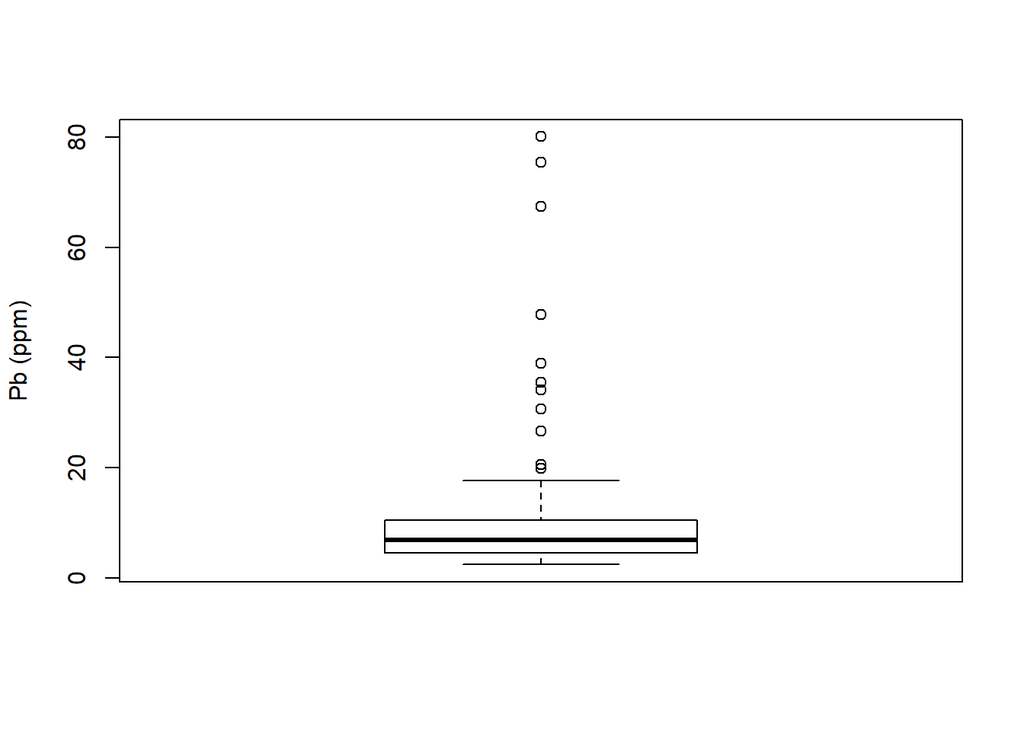

```r
outap_Ba <- geochem_ap[-which(geochem_ap$Ba_ppm %in% outliersBa),]

#Removing outliers from Pb concentrations
outliersPb <- boxplot(geochem_ap$Pb_ppm, ylab="Pb (ppm)")$out
```

```r
print("Pb outliers:")
```

```
## [1] "Pb outliers:"
```

```r
print(outliersPb)
```

```
##  [1] 34.08 75.45 19.83 80.06 26.71 47.83 35.45 39.02 30.70 20.59 67.37
```

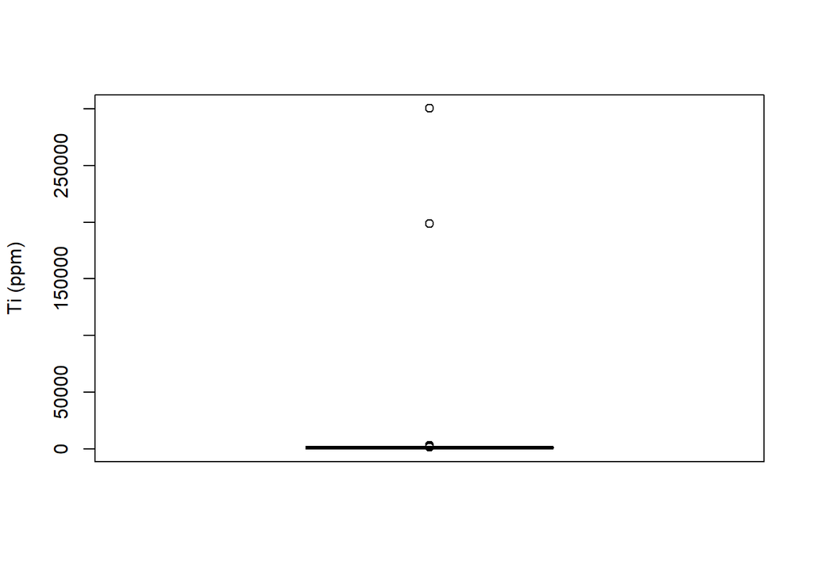

```r
outap_Pb <- geochem_ap[-which(geochem_ap$Pb_ppm %in% outliersPb),]

#Removing outliers from Ti concentrations
outliersTi <- boxplot(geochem_ap$Ti_ppm, ylab="Ti (ppm)")$out
```

```r
print("Ti outliers:")
```

```
## [1] "Ti outliers:"
```

```r
print(outliersTi)
```

```
##  [1]   2210.80   1157.41 198589.36   1280.66   2950.83   1128.25   1299.73
##  [8]   1477.82   1831.62 300480.09
```

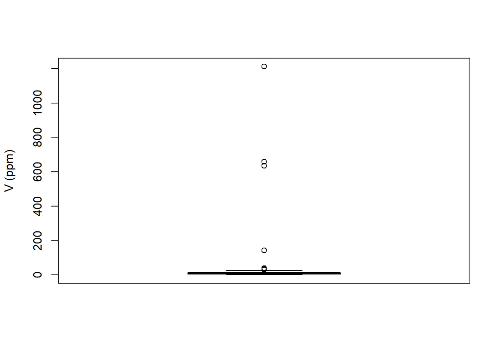

```r
outap_Ti <- geochem_ap[-which(geochem_ap$Ti_ppm %in% outliersTi),]

#Removing outliers from V concentrations
outliersV <- boxplot(geochem_ap$V_ppm, ylab="V (ppm)")$out
```

```r
print("V outliers:")
```

```
## [1] "V outliers:"
```

```r
print(outliersV)
```

```
## [1]   40.42   30.65   36.12  658.19  635.43  142.85 1211.60
```

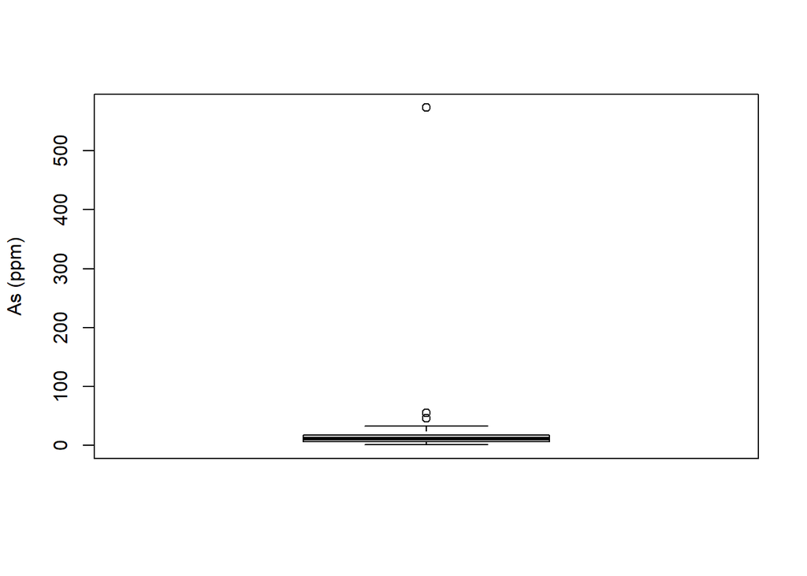

```r
outap_V <- geochem_ap[-which(geochem_ap$V_ppm %in% outliersV),]

#Removing outliers from As concentrations
outliersAs <- boxplot(geochem_ap$As_ppm, ylab="As (ppm)")$out
```

```r
print("As outliers:")
```

```
## [1] "As outliers:"
```

```r
print(outliersAs)
```

```
## [1]  55.19  46.09 573.08
```

```r
outap_As <- geochem_ap[-which(geochem_ap$As_ppm %in% outliersAs),]
```

```r
SumLREE <- (geochem_ap[,"La_ppm"]+geochem_ap[,"Ce_ppm"]+geochem_ap[,"Pr_ppm"]+
              geochem_ap[,"Nd_ppm"]+geochem_ap[,"Sm_ppm"])
SumHREE <- (geochem_ap[,"Gd_ppm"]+geochem_ap[,"Tb_ppm"]+geochem_ap[,"Dy_ppm"]+
              geochem_ap[,"Ho_ppm"]+geochem_ap[,"Er_ppm"]+geochem_ap[,"Tm_ppm"]+
              geochem_ap[,"Yb_ppm"]+geochem_ap[,"Lu_ppm"])
LaSm <- ((geochem_ap[,"La_ppm"]/0.237)/(geochem_ap[,"Sm_ppm"]/0.148))
eueu <- ((geochem_ap[,"Eu_ppm"]/0.0563)*
           (((geochem_ap[,"Sm_ppm"]/0.148)*(geochem_ap[,"Gd_ppm"]/0.199)))^-0.5)
cece <- ((geochem_ap[,"Ce_ppm"]/0.613)*
           (((geochem_ap[,"La_ppm"]/0.237)*(geochem_ap[,"Pr_ppm"]/0.0928)))^-0.5)

geochem_ap$SumLREE=SumLREE
geochem_ap$SumHREE=SumHREE
geochem_ap$LaSm=LaSm
geochem_ap$eueu=eueu
geochem_ap$cece=cece
```

Once the corrections are made, we visualise the multielements boxplots via:

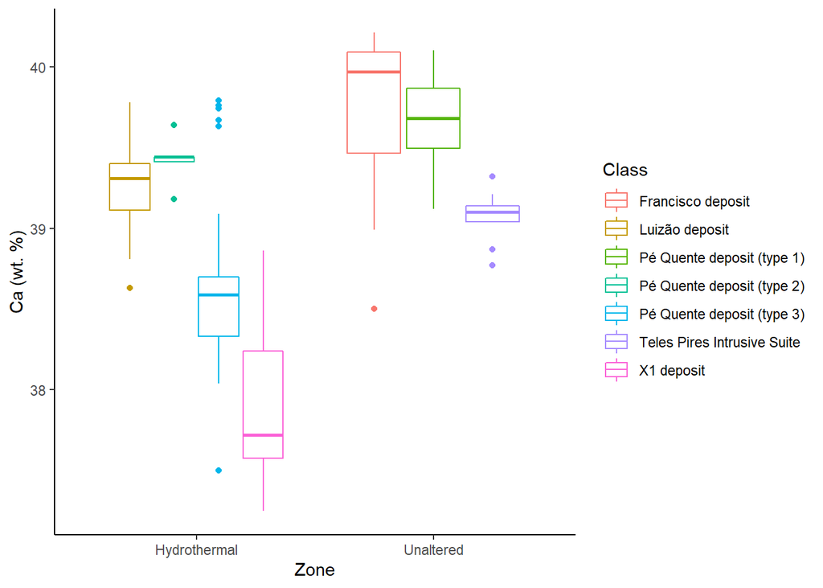

```r
qplot(Zone, Ca_pct, data=geochem_ap, geom="boxplot", colour=Class, ylab="Ca (wt. %)")
```

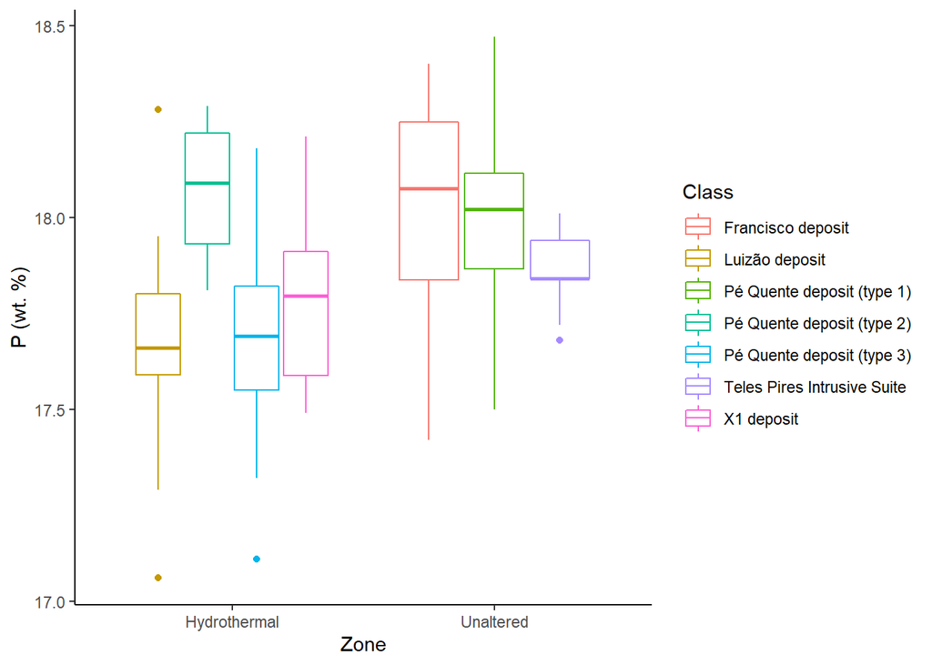

```r
qplot(Zone, P_pct, data=geochem_ap, geom="boxplot", colour=Class, ylab="P (wt. %)")
```

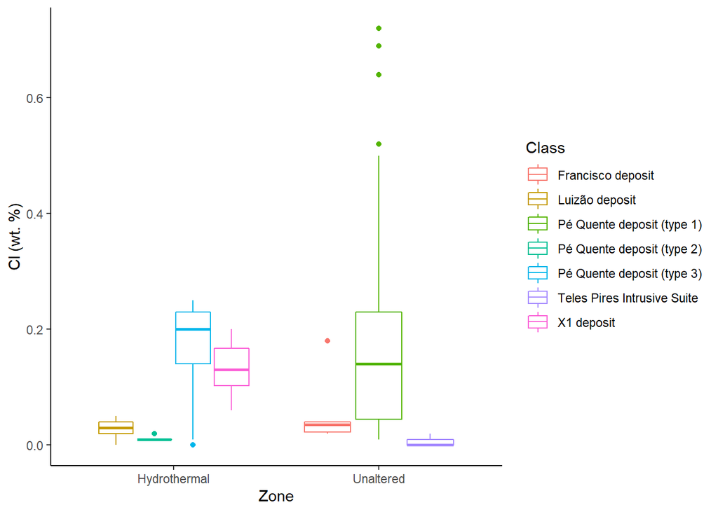

```r
qplot(Zone, Cl_pct, data=geochem_ap, geom="boxplot", colour=Class, ylab="Cl (wt. %)")
```

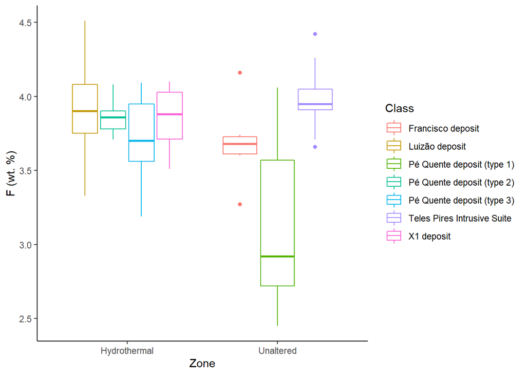

```r
qplot(Zone, F_pct, data=geochem_ap, geom="boxplot", colour=Class, ylab="F (wt. %)")
```

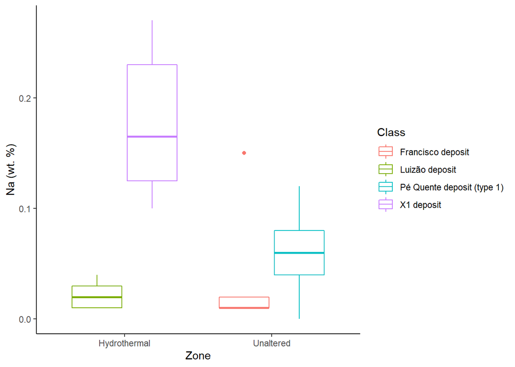

```r
qplot(Zone, Na_pct, data=geochem_ap, geom="boxplot", colour=Class, ylab="Na (wt. %)")
```

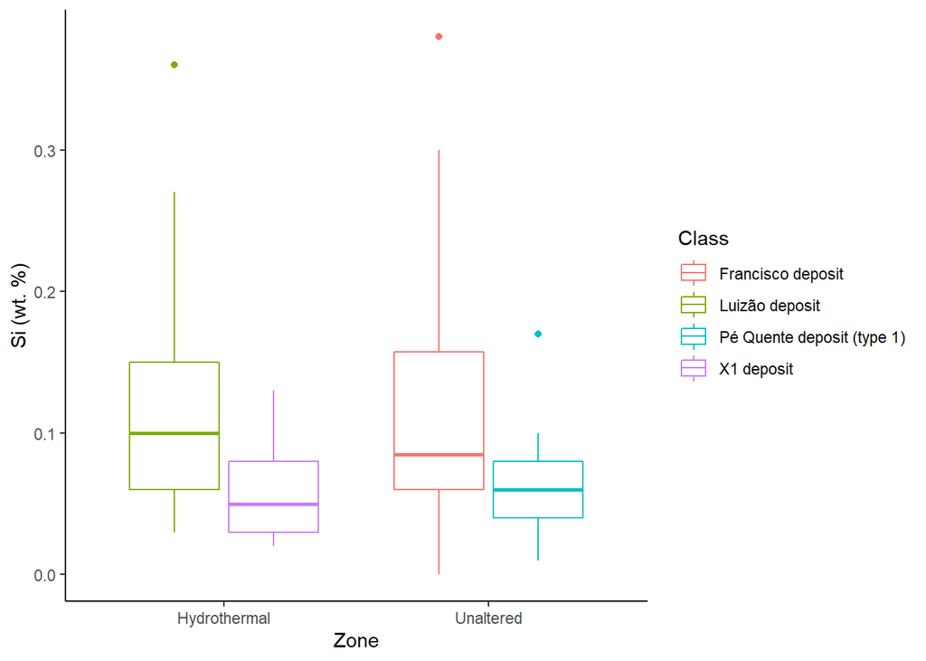

```r
qplot(Zone, Si_pct, data=geochem_ap, geom="boxplot", colour=Class, ylab="Si (wt. %)")
```

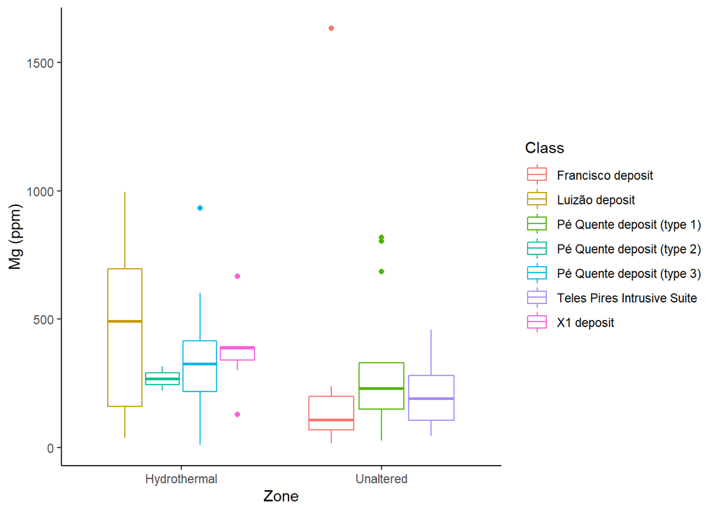

```r
qplot(Zone, Mg_ppm, data=outap_Mg, geom="boxplot", colour=Class, ylab="Mg (ppm)")
```

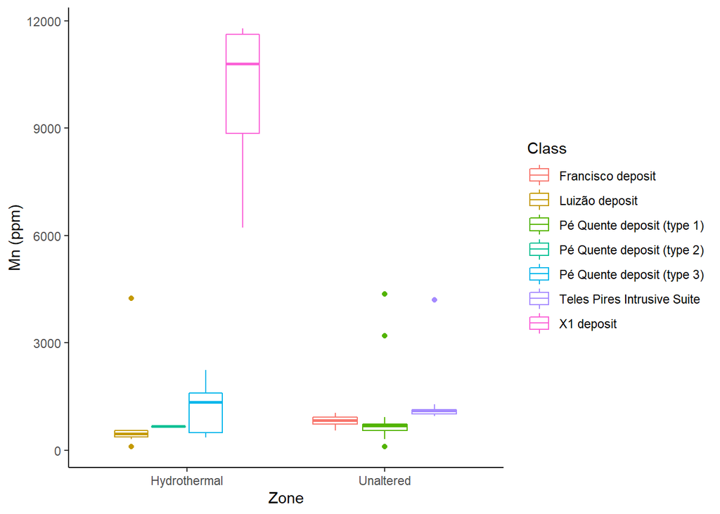

```r
qplot(Zone, Mn_ppm, data=geochem_ap, geom="boxplot", colour=Class, ylab="Mn (ppm)")
```

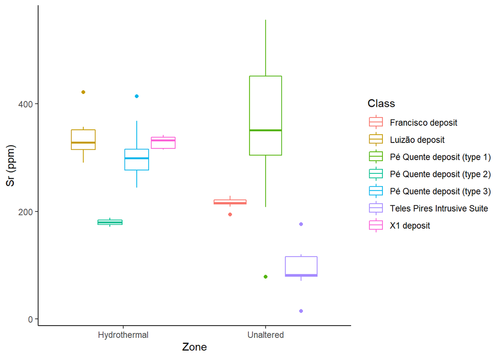

```r
qplot(Zone, Sr_ppm, data=outap_Sr, geom="boxplot", colour=Class, ylab="Sr (ppm)")
```

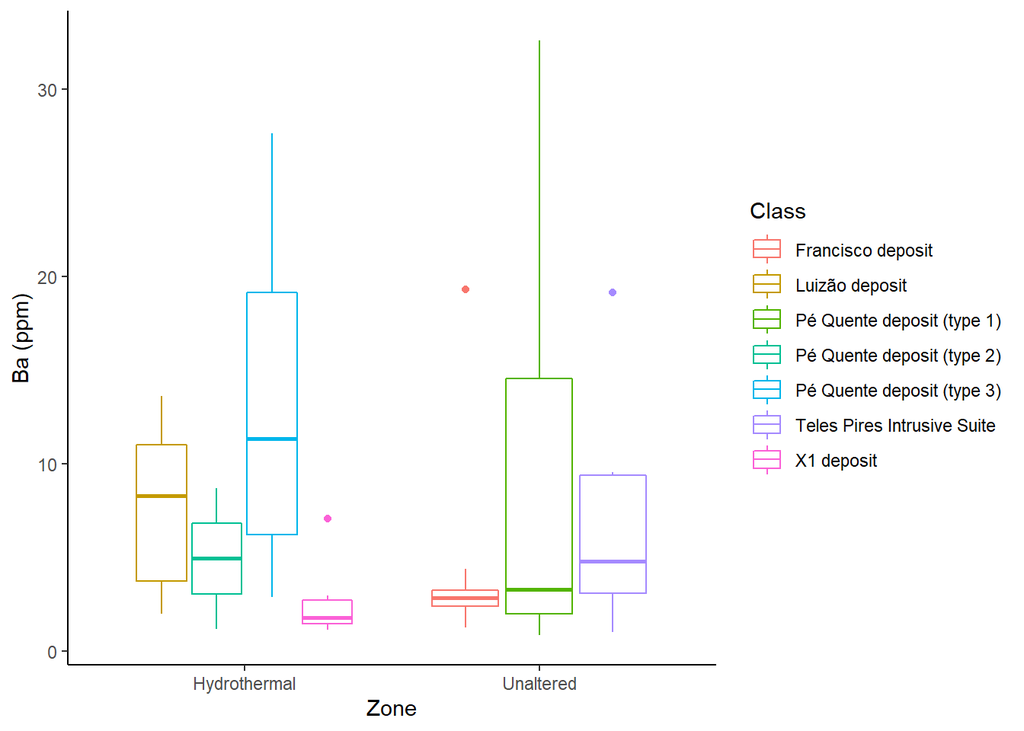

```r
qplot(Zone, Ba_ppm, data=outap_Ba, geom="boxplot", colour=Class, ylab="Ba (ppm)")
```

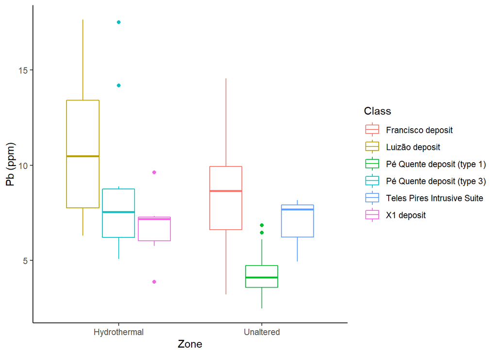

```r
qplot(Zone, Pb_ppm, data=outap_Pb, geom="boxplot", colour=Class, ylab="Pb (ppm)")
```

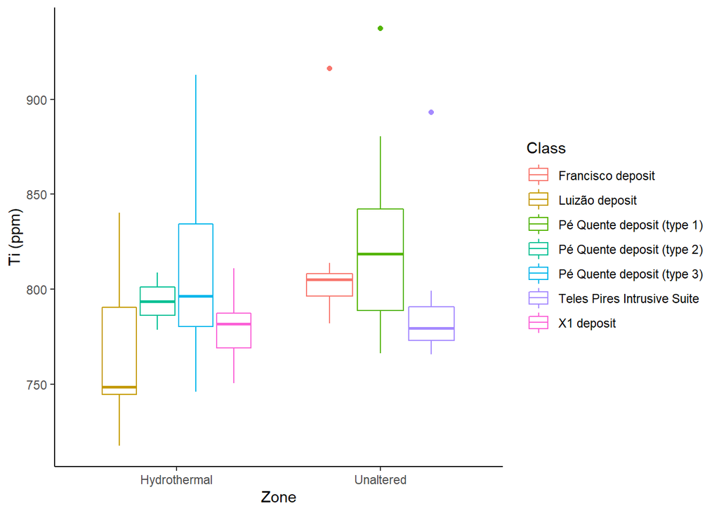

```r
qplot(Zone, Ti_ppm, data=outap_Ti, geom="boxplot", colour=Class, ylab="Ti (ppm)")
```

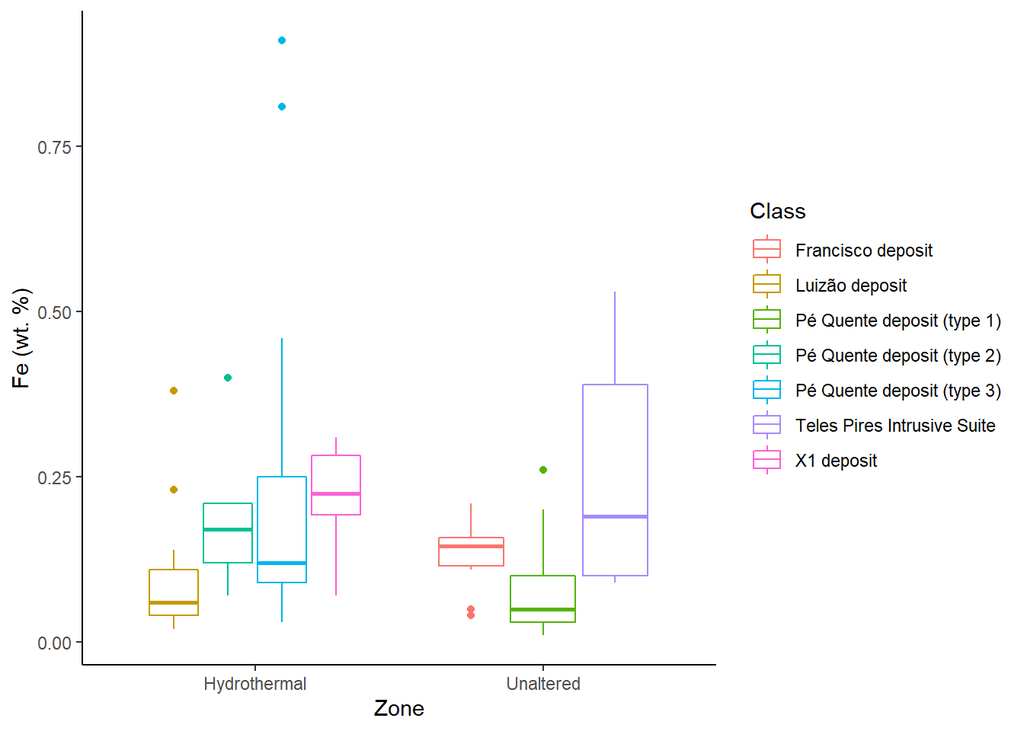

```r
qplot(Zone, Fe_pct, data=geochem_ap, geom="boxplot", colour=Class, ylab="Fe (wt. %)")
```

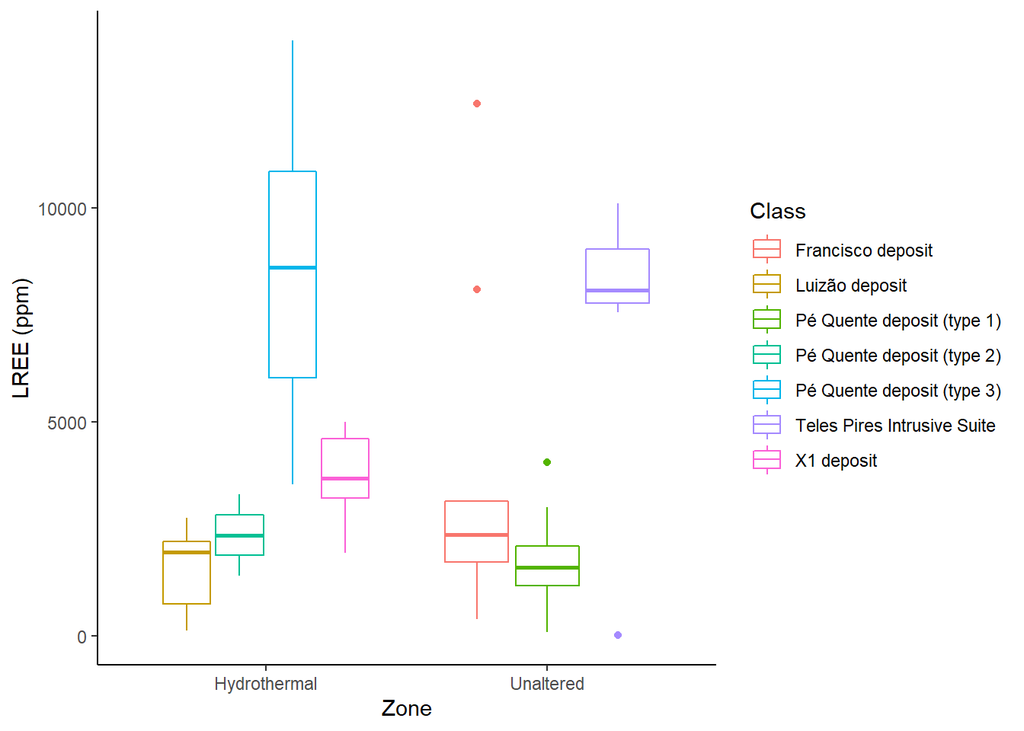

```r
qplot(Zone, SumLREE, data=geochem_ap, geom="boxplot", colour=Class, ylab="LREE (ppm)")
```

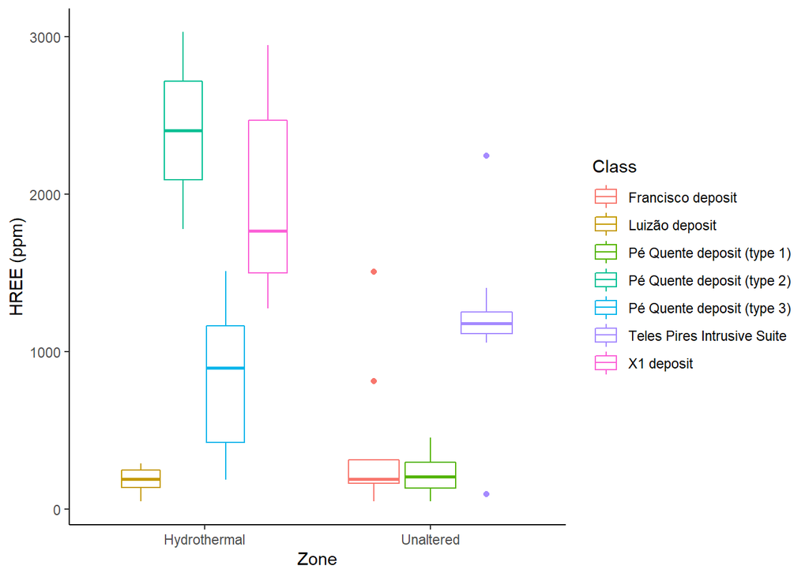

```r
qplot(Zone, SumHREE, data=geochem_ap, geom="boxplot", colour=Class, ylab="HREE (ppm)")
```

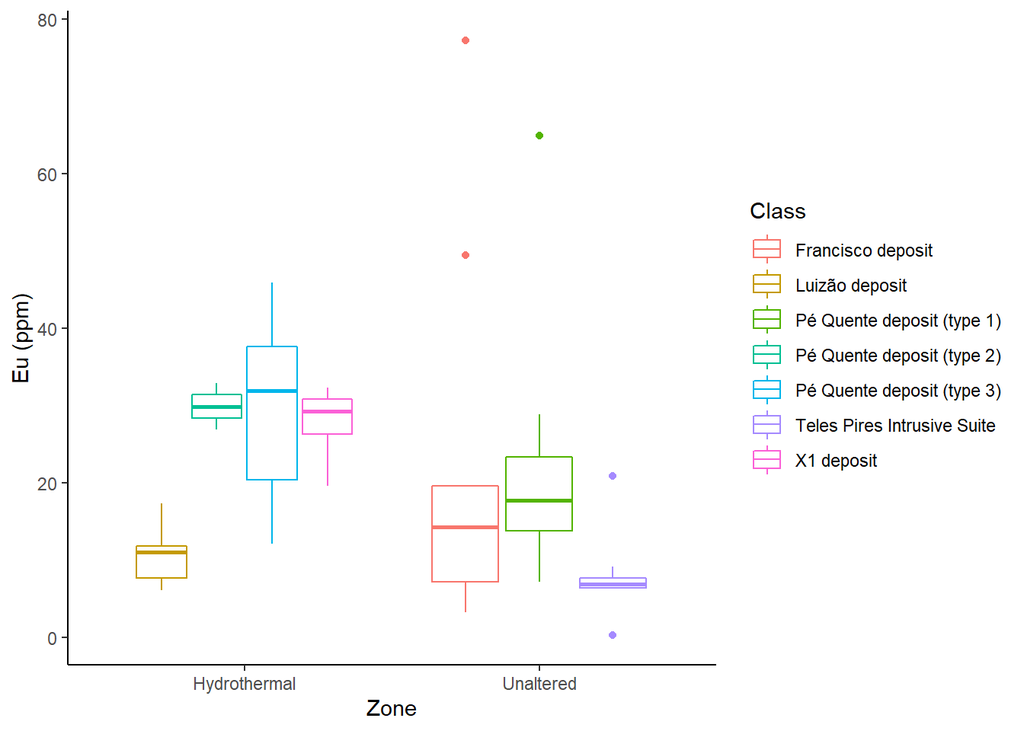

```r
qplot(Zone, Eu_ppm, data=geochem_ap, geom="boxplot", colour=Class, ylab="Eu (ppm)")
```

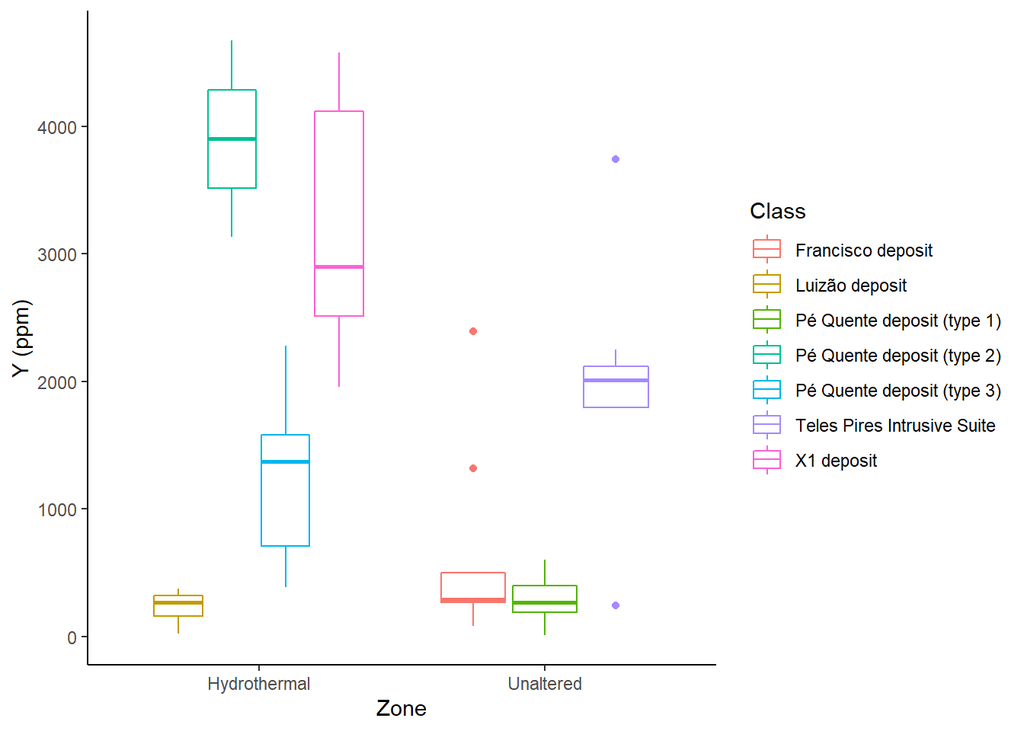

```r
qplot(Zone, Y_ppm, data=geochem_ap, geom="boxplot", colour=Class, ylab="Y (ppm)")
```

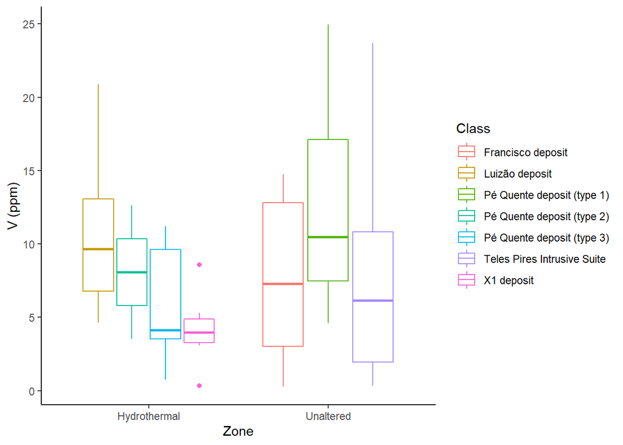

```r
qplot(Zone, V_ppm, data=outap_V, geom="boxplot", colour=Class, ylab="V (ppm)")
```

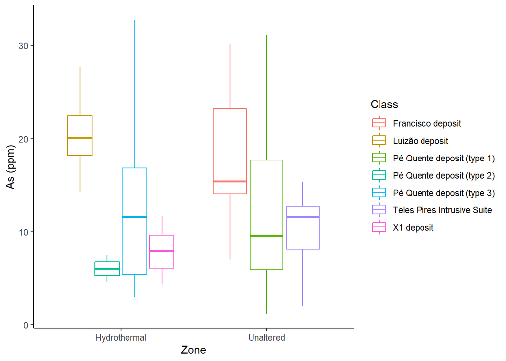

```r
qplot(Zone, As_ppm, data=outap_As, geom="boxplot", colour=Class, ylab="As (ppm)")
```

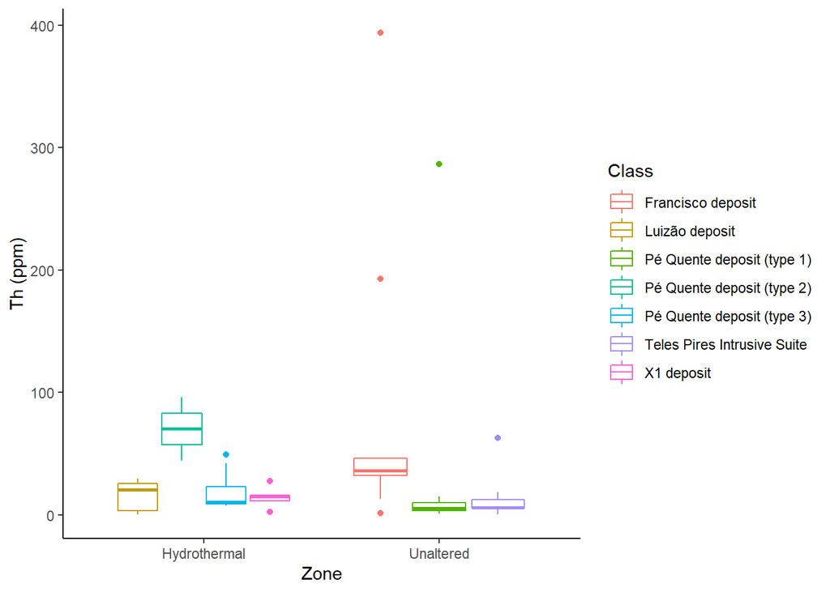

```r
qplot(Zone, Th232_ppm, data=geochem_ap, geom="boxplot", colour=Class, ylab="Th (ppm)")
```

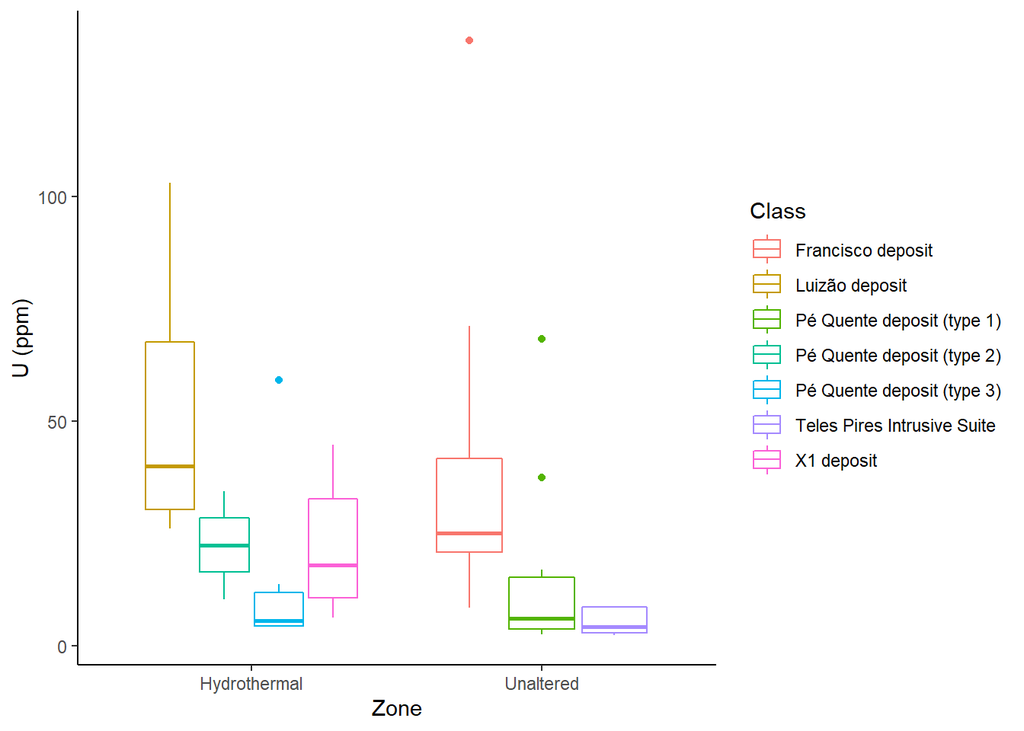

```r
qplot(Zone, U238_ppm.1, data=geochem_ap, geom="boxplot", colour=Class, ylab="U (ppm)")
```

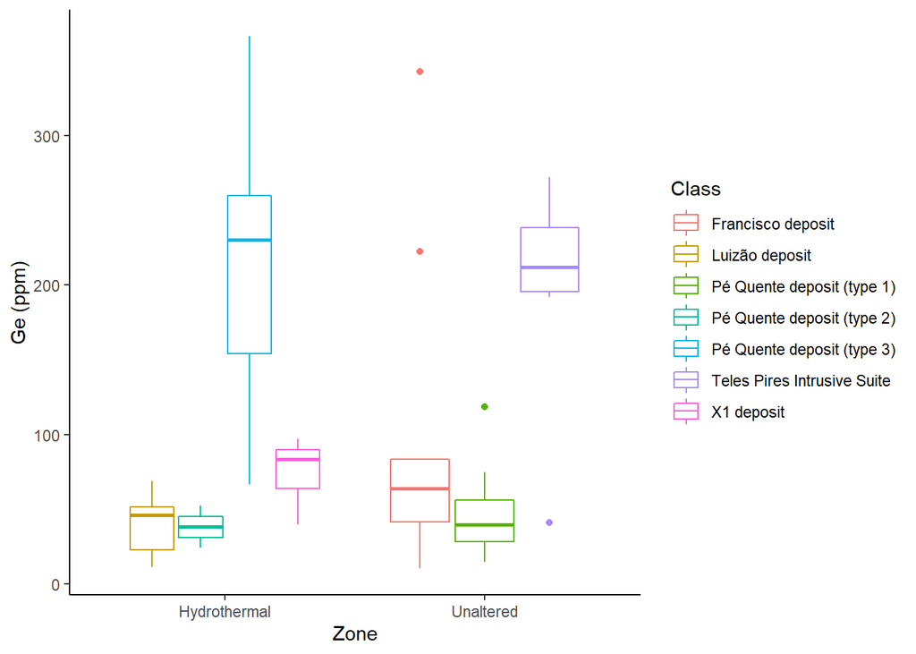

```r
qplot(Zone, Ge_ppm, data=geochem_ap, geom="boxplot", colour=Class, ylab="Ge (ppm)")
```

The meaning of the subtitles is discussed in *Chapter 5* of the complete dissertation, about Petrography. The thoroughly description of the boxplots and their relationships is described in *Chapter 6*, about Geochemistry.

As you can probably sense by now, examining all those boxplots can be exaustive and somewhat inconclusive. A better way of evaluating that data would be to apply more advanced statistical techniques, generally referred to as **multivariate discriminant analysis**, in which we reduce the dimensionallity of the data. Each trace element, e.g. variable, opens up a new mathematical dimension onto which the data may pivot itself. Understanding the real geometrical dimension of this data may require statistical tools that are known in the machine learning community, such as Principal Component Analysis (PCA).

For PCA and other multivariate discriminant analysis, see [Part 2](https://github.com/pedroafleite/trace-elements-apatite-magnetite/blob/main/part2_apatite_discriminant.md).